# Laboratório 3 - Parte 1: Entendendo os dados

Arthur Lustosa

Nosso objetivo nessa análise é entender os dados, fazer uma análise descritiva para nos ajudar a responder algumas perguntas sobre classificação.

Para nosso auxilio, utilizaremos as bibliotecas a seguir

```r
library(dplyr)
library(ggplot2)
library(plotly)
```

Primeiro vamos ler os dados que iremos trabalhar

```r
treino_classificação <- read.csv("dados/treino_classificacao.csv")
colnames(treino_classificação) <- c("Matricula", "Matricula_Turma", "Disciplina", "Ano", "Periodo","Media_Final", "Evadiu")
```

Os dados são referentes ao histórico dos alunos do primeiro período de 2000 a 2015, e possuem os seguintes atributos:

1. Matricula: Matrícula aluno (anonimizado)
2. Matricula_Turma: Código Disciplina
3. Disciplina: Nome Disciplina
4. Ano: Ano da matrícula
5. Media_Final: Média obtida na disciplina
6. Evadiu: Variável-alvo que indica se o aluno evadiu ou não ao término do período.

## 1. Qual foi o ano em que houve mais evasões?

```r
n_evasoes <- treino_classificação %>%
  select(Matricula, Ano, Evadiu) %>%
  distinct() %>%
  group_by(Ano) %>%
  summarise(n_evasoes = sum(Evadiu))
```

[interactive chart not shown]

No gráfico acima podemos ver que o ano em que ocorreram mais evasões foi o ano de 2011. Num total de 113 alunos, 9 evadiram, aproximadamente 7.96% dos alunos.

## 2. Distribuição das Classes

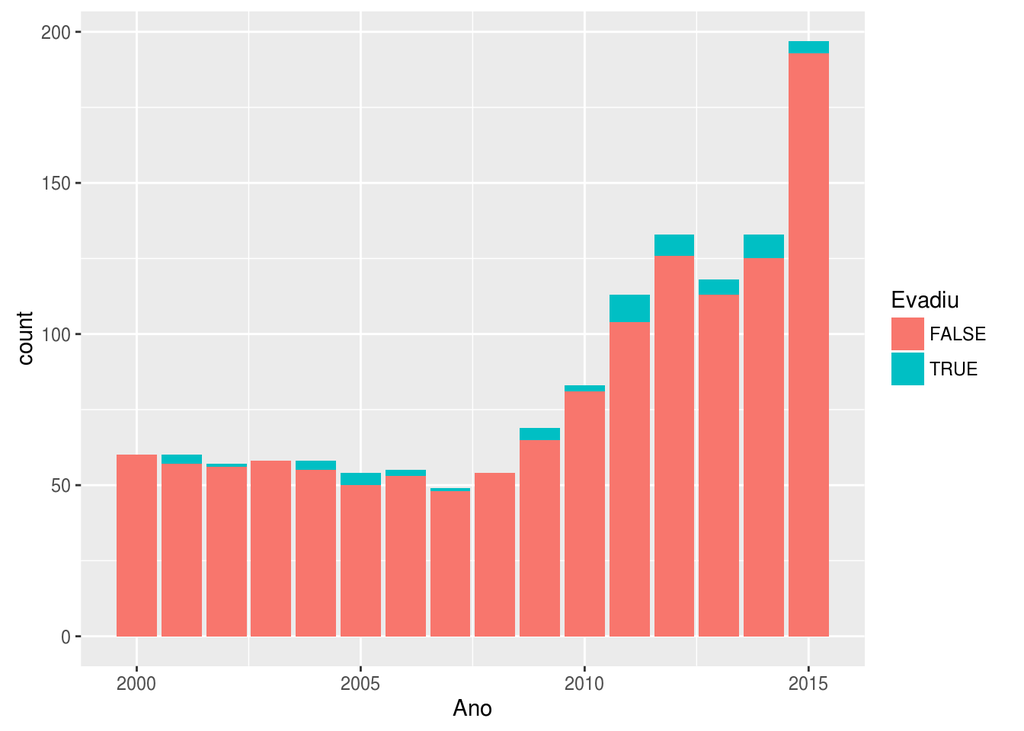

```r
distribuicao_classes <- treino_classificação %>%
  select(Matricula, Ano, Evadiu) %>%
  distinct() %>%
  group_by(Ano, Evadiu) %>%
  summarise(count = n())


ggplot(data=distribuicao_classes, aes(x=Ano, y=count, fill=Evadiu)) +
geom_bar(stat="identity")
```

Analisando o gráfico da distribuição das classes, percebemos a ocorrência de um grande desbalanceamento, pois a maioria dos alunos não abandonam o curso. No algoritmo de predição o desbalanceamento pode causar a diminuição da acurácia, diminuindo a performance do algoritmo e fazendo com que ela seja tendenciosa para a classe majoritária, no nosso caso a permanência do aluno no curso. Isso ocorre porque os algoritmos assumem que os dados possuem distruibuição balanceada e assim consideram que os erros obtidos pelas classes possuem o mesmo custo, o que não se aplica quando há desbalanceamento.

## 3. Desbalanceamento das Classes

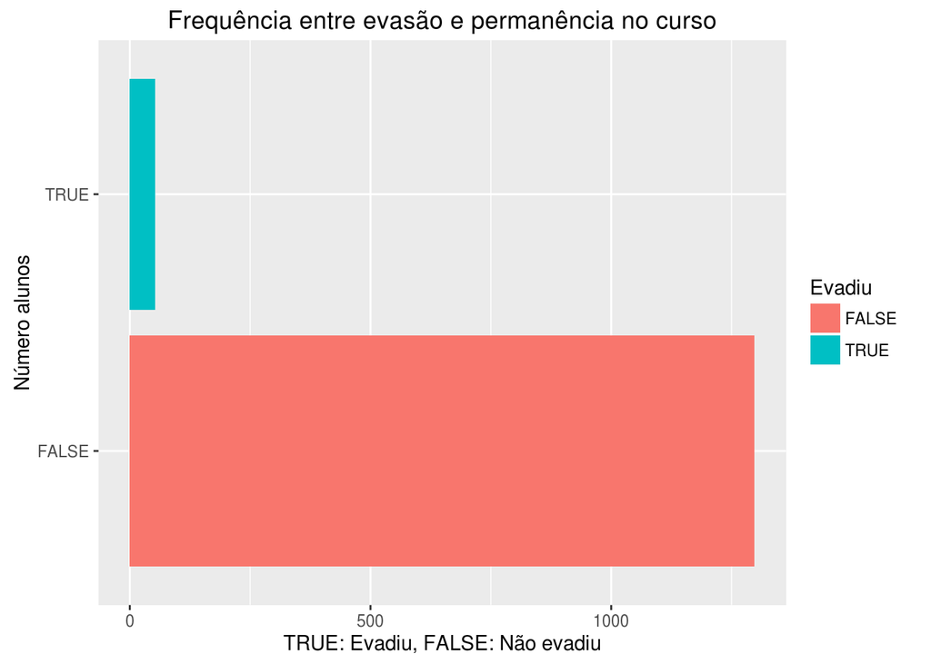

```r
ggplot(data=distribuicao_classes, aes(x=Evadiu, y=count, fill=Evadiu)) +
geom_bar(stat="identity") +
  coord_flip() +
  labs(title = "Frequência entre evasão e permanência no curso",
       x = "Número alunos", y = "TRUE: Evadiu, FALSE: Não evadiu")
```

Sim, observando o gráfico da distribuição das classes percebemos a ocorrência da instância FALSE (não ocorrência de evasão) do que TRUE (ocorrência de evasao). A proporção é de aproximadamente FALSE 96.1% e TRUE 3.9%.

Como foi mencionado, com classes desbalanceadas, o classificador pode se tornar enviesado para a classe majoritária. Os algoritmos de classificassão tentam diminuir o erro geral da previsão, porém com classes desbalanceadas o erro pode não ser percebido.

## 4. Novo atributo

```r
novo_atributo = group_by(treino_classificação, Matricula) %>% mutate(count = n(), n_reprovacoes = sum(Media_Final < 5))
```

O atributo criado foi a contagem do número de reprovações que o aluno teve. Para isso, analisando as notas finais nas disciplinas, caso fosse < 5 o aluno foi reprovado, fiz a contagem dessas ocorrências e armazenei numa coluna.

No gráfico abaixo podemos ver a relação entre o número de reprovações e a permanência, ou a saída, do aluno no curso. No caso da ocorrência da evasão do curso, vemos que o número de reprovações se matêm distribuído constante, já na permanência do aluno no curso, esse número varia e sua maior concentração é próximo a zero, porém mesmo ocorrendo algumas reprovações o aluno não desistiu.

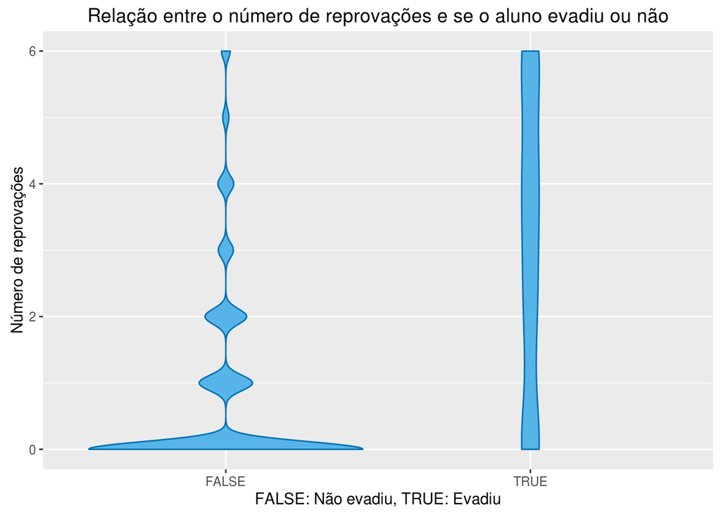

```r
n_rep <- c(0, 1, 2, 3, 4, 5, 6)
ggplot(data = novo_atributo, aes(x = Evadiu, y = n_reprovacoes)) +
  geom_violin(scale="area", fill="#56B4E9", colour="#0072B2") +
  labs(title = "Relação entre o número de reprovações e se o aluno evadiu ou não",
       x = "FALSE: Não evadiu, TRUE: Evadiu", y = "Número de reprovações")
```